# Prediction from Accelerometers Data

## Executive Summary

```r
  library(caret)
```

First, the data is downloaded and copied to the data folder of the current working directory.

Then, it is loaded using read.csv.

```r
  data <- read.csv("data/pml-training.csv")
  summary(data)
```

```
##        X            user_name    raw_timestamp_part_1 raw_timestamp_part_2
##  Min.   :    1   adelmo  :3892   Min.   :1.32e+09     Min.   :   294
##  1st Qu.: 4906   carlitos:3112   1st Qu.:1.32e+09     1st Qu.:252912
##  Median : 9812   charles :3536   Median :1.32e+09     Median :496380
##  Mean   : 9812   eurico  :3070   Mean   :1.32e+09     Mean   :500656
##  3rd Qu.:14717   jeremy  :3402   3rd Qu.:1.32e+09     3rd Qu.:751891
##  Max.   :19622   pedro   :2610   Max.   :1.32e+09     Max.   :998801
##
##           cvtd_timestamp  new_window    num_window    roll_belt
##  28/11/2011 14:14: 1498   no :19216   Min.   :  1   Min.   :-28.9
##  05/12/2011 11:24: 1497   yes:  406   1st Qu.:222   1st Qu.:  1.1
##  30/11/2011 17:11: 1440               Median :424   Median :113.0
##  05/12/2011 11:25: 1425               Mean   :431   Mean   : 64.4
##  02/12/2011 14:57: 1380               3rd Qu.:644   3rd Qu.:123.0
##  02/12/2011 13:34: 1375               Max.   :864   Max.   :162.0
##  (Other)         :11007
##    pitch_belt        yaw_belt      total_accel_belt kurtosis_roll_belt
##  Min.   :-55.80   Min.   :-180.0   Min.   : 0.0              :19216
##  1st Qu.:  1.76   1st Qu.: -88.3   1st Qu.: 3.0     #DIV/0!  :   10
##  Median :  5.28   Median : -13.0   Median :17.0     -1.908453:    2
##  Mean   :  0.31   Mean   : -11.2   Mean   :11.3     -0.016850:    1
##  3rd Qu.: 14.90   3rd Qu.:  12.9   3rd Qu.:18.0     -0.021024:    1
##  Max.   : 60.30   Max.   : 179.0   Max.   :29.0     -0.025513:    1
##                                                     (Other)  :  391
##  kurtosis_picth_belt kurtosis_yaw_belt skewness_roll_belt
##           :19216            :19216              :19216
##  #DIV/0!  :   32     #DIV/0!:  406     #DIV/0!  :    9
##  47.000000:    4                       0.000000 :    4
##  -0.150950:    3                       0.422463 :    2
##  -0.684748:    3                       -0.003095:    1
##  -1.750749:    3                       -0.010002:    1
##  (Other)  :  361                       (Other)  :  389
##  skewness_roll_belt.1 skewness_yaw_belt max_roll_belt   max_picth_belt
##           :19216             :19216     Min.   :-94     Min.   : 3
##  #DIV/0!  :   32      #DIV/0!:  406     1st Qu.:-88     1st Qu.: 5
##  0.000000 :    4                        Median : -5     Median :18
##  -2.156553:    3                        Mean   : -7     Mean   :13
##  -3.072669:    3                        3rd Qu.: 18     3rd Qu.:19
##  -6.324555:    3                        Max.   :180     Max.   :30
##  (Other)  :  361                        NA's   :19216   NA's   :19216
```

[output cut: 289 more lines]

```
##  Min.   : -8.09   Min.   :-498.0   Min.   :-632    Min.   :-446.0
##  1st Qu.: -0.18   1st Qu.:-178.0   1st Qu.:  57    1st Qu.:-182.0
##  Median :  0.08   Median : -57.0   Median : 201    Median : -39.0
##  Mean   :  0.15   Mean   : -61.7   Mean   : 164    Mean   : -55.3
##  3rd Qu.:  0.49   3rd Qu.:  76.0   3rd Qu.: 312    3rd Qu.:  26.0
##  Max.   :231.00   Max.   : 477.0   Max.   : 923    Max.   : 291.0
##
##  magnet_forearm_x magnet_forearm_y magnet_forearm_z classe
##  Min.   :-1280    Min.   :-896     Min.   :-973     A:5580
##  1st Qu.: -616    1st Qu.:   2     1st Qu.: 191     B:3797
##  Median : -378    Median : 591     Median : 511     C:3422
##  Mean   : -313    Mean   : 380     Mean   : 394     D:3216
##  3rd Qu.:  -73    3rd Qu.: 737     3rd Qu.: 653     E:3607
##  Max.   :  672    Max.   :1480     Max.   :1090
##
```

As can be seen from the summary, only some columns can be used for prediction. Some columns like started by kurtosis and avg suggest that those columns are derived features and will not be used as predictors. Furthermore, those features have many NAs or invalid values such as #Div/0!.

This ends up with the following columns:

```r
  sub <- data[,c(8:11, 37:49, 60:68, 84:86,113:124, 151:160)]
```

where 160 is the ‘classe’ column.

50 features obtained from the operation above are used to predict the classe. Three classification methods are compared to select the best method:

- linear discriminant analysis (lda)
- boosting (gbm)
- random forest (rf)

```r
# make sure all trainings to use the same trainControl
fitControl <- trainControl(## 20-fold CV
                           method = "cv",
                           number = 20)
set.seed(820)
ldaFit <- train(classe ~ ., data = sub, method = "lda",
                trControl=fitControl)
ldaFit
```

```
## Linear Discriminant Analysis
##
## 19622 samples
##    50 predictors
##     5 classes: 'A', 'B', 'C', 'D', 'E'
##
## No pre-processing
## Resampling: Cross-Validated (20 fold)
##
## Summary of sample sizes: 18640, 18641, 18641, 18640, 18642, 18642, ...
##
## Resampling results
##
##   Accuracy  Kappa  Accuracy SD  Kappa SD
##   0.7       0.6    0.02         0.02
##
##
```

```r
set.seed(820)
gbmFit <- train(classe ~ ., data = sub, method = "gbm",
                trControl=fitControl)
gbmFit
```

[output not shown]

```r
set.seed(820)
rfFit <- train(classe ~ ., data = sub, method = "rf",
                trControl=fitControl)
rfFit
```

```
## Random Forest
##
## 19622 samples
##    50 predictors
##     5 classes: 'A', 'B', 'C', 'D', 'E'
##
## No pre-processing
## Resampling: Cross-Validated (20 fold)
##
## Summary of sample sizes: 18640, 18641, 18641, 18640, 18642, 18642, ...
##
## Resampling results across tuning parameters:
##
##   mtry  Accuracy  Kappa  Accuracy SD  Kappa SD
##   2     1         1      0.002        0.002
##   30    1         1      0.002        0.003
##   50    1         1      0.003        0.004
##
## Accuracy was used to select the optimal model using  the largest value.
## The final value used for the model was mtry = 2.
```

Once trained, the models are compared using resampling. This is done using resamples function of caret.

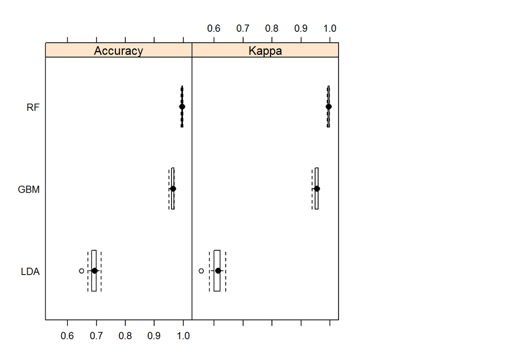

```r
resamps <- resamples(list(LDA = ldaFit,
                          GBM = gbmFit,
                          RF  = rfFit))
trellis.par.set(caretTheme())
bwplot(resamps, layout = c(3, 1))
```

```r
summary(resamps)
```

```
##
## Call:
## summary.resamples(object = resamps)
##
## Models: LDA, GBM, RF
## Number of resamples: 20
##
## Accuracy
##      Min. 1st Qu. Median  Mean 3rd Qu.  Max. NA's
## LDA 0.648   0.684  0.695 0.692   0.699 0.717    0
## GBM 0.951   0.960  0.964 0.963   0.967 0.968    0
## RF  0.993   0.995  0.996 0.996   0.998 0.999    0
##
## Kappa
##      Min. 1st Qu. Median  Mean 3rd Qu.  Max. NA's
## LDA 0.555   0.601  0.614 0.610   0.619 0.640    0
## GBM 0.938   0.949  0.955 0.953   0.959 0.960    0
## RF  0.991   0.994  0.995 0.995   0.997 0.999    0
```

As we can see, the random forests model is in general better than the other two. Therefore the model is used for the prediction purpose.

The prediction can be done then as follow:

```r
 testing <- read.csv("data/pml-testing.csv")
 resp    <- predict(rfFit, newdata=testing)
resp
```

```
##  [1] B A B A A E D B A A B C B A E E A B B B
## Levels: A B C D E
```